# IS 6813: EDA Assignment

Author

Sabrina Lin

Published

October 6, 2025

## Libraries

```r
library(dplyr)
library(tidyverse)
library(reticulate)
```

## Introduction

### Business Problem Statement

Swire Coca-Cola’s MyCoke360 platform has been experiencing instances of cart abandonment, where customers add products to their cart but fail to complete their orders by the next order date. This behavior can lead to lost revenue and operational inefficiencies. Repeated abandonment can be due to a multitude of factors, such as pricing issues or misalignment with customer needs, and understanding these factors is critical to improving order completion and reducing revenue leakage.

### Analytics Approach and Challenges

The target variable is a binary variable, where a 1 would indicate that a customer is expected to abandon their cart given a specified order window or 0 when they do not abandon their cart given a specified order window. However, the largest challenge has been defining that order window as it changes depending on the frequency and policy start date. A customer can order multiple times throughout the year, so the order window changes and determining which weeks customers abandon and do not abandon their carts has been tricky.

A large amount of the data is categorical, as such, our team would like to continue into the modeling phase with a rough idea of using a classification model to see if the trends we’ve uncovered during our EDA phase translate well into that type of prediction model. Our focus is on pattern recognition and tracking habits of customers that tend to abandon their carts. From the EDA itself, it seems like a lot of differences arise in terms of location, with more remote locations struggling. Another aspect we’ve seen is that the interface of MyCoke360 may be contributing to customers abandoning carts, perhaps an indication that it is a struggle to use for many customers.

### Questions

1. How do we calculate order window? Which variables do we need? How can we translate that into a binary predictor?
2. If ANCHOR_DATE is the supposed ‘start date’ of when the order window begins, is it reasonable to say that a week later is the cut-off date?
3. The materials table has an insane amount of detail - is all of this really necessary or contributes to cart abandonment? It’s not like it’s harder to order one product over another? Do we even need to use this table?
4. All pages and events have occurred on the MyCoke360 website correct?
5. Is PHYSICAL_VOLUME a multiplier of ITEM?
6. The Visit Plan data table has enough rows to crash R, what is the best sample size to take from that table? (and subsequent other tables)
7. A lot of columns describe one another in either more or less detail - how can we reduce as it seems like colinearity is occurring?
8. It is easy to assume that locations with high revenue typically won’t abandon carts in order to keep up with the demand - is that the case and can we focus on the stores that don’t have that?
9. Need to find ways to bucket and determine standout factors - what is different between the locations that could contribute to an abandoned cart?
10. Don’t forget about interface itself - does mobile v. desktop have a stark enough difference to contribute to an abandoned cart?

## Description of Data

The data includes 8 CSV files that house detailed information related to MyCoke360 orders and activity. Each file contains information as below:

- google_analytics.csv - Contains information regarding specific website events.
- orders.csv - Tracks customer orders and when they were placed at the material level
- sales.csv - Records financial details of the products sold(Note: products may differ slightly due to out of stocks)
- visit_plan.csv - Contains historical order placement(visit plan) data for each customer and the anchor date(the day they must order by)
- customer.csv - Provides information on customers such as where they order from and what type of customer channel they are such as restaurant, wholesaler, etc. This table had some collinearity present such as SALES_OFFICE and SALES_OFFICE_DESCRIPTION as well as CUSTOMER_SUB_TRADE_CHANNEL_DESCRIPTION and DISTRIBUTION_MODE_DESCRIPTION columns.
- cutoff_times.csv - Gives us the specific time of day a customer must have their order in by and exceptions made
- operating_hours.csv - Gives us current information on visit plans
- material.csv - Provides specific information on products such as category, brand, flavor, pack size, and type. Found within the material data is that all items listed have unique MATERIAL_ID, but the combination of the other columns are duplicated.

## Description of Missing Data

For the most part, there was very few NA’s present across all the data tables. Only one column had any missing data for the material.csv. BEV_CAT_DESC was missing for 134 rows. The rest of the rows for these 134 all showed the same trade mark and flavor description but varied in pack type and size. The operating_hours CSV has no missing values and no duplicates and the cutoff_times.csv also has no missing values; however, it has Cutoff times for orders, currently as strings, and shipping duration stored as strings, which need conversion to numeric for analysis.

## Exploratory Visualizations and/or Summary Tables

### Pre-face

Due to individuals using a combination of Python and R along with the large data sets, for the sake of simplicity, the Python code has been added but commented out. The code has been appended to a separate section in order to provide a quick and clear look at the visualizations.

### Courtney

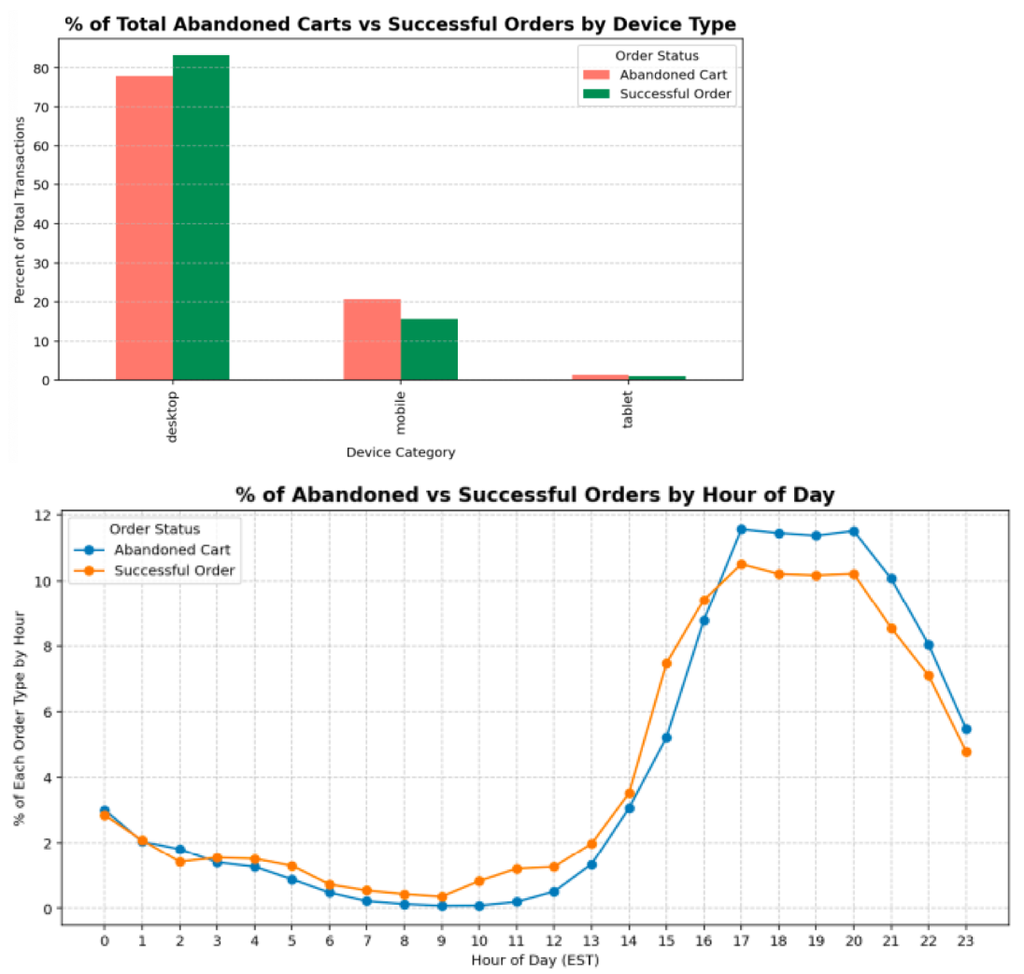

Courtney Graphs 1

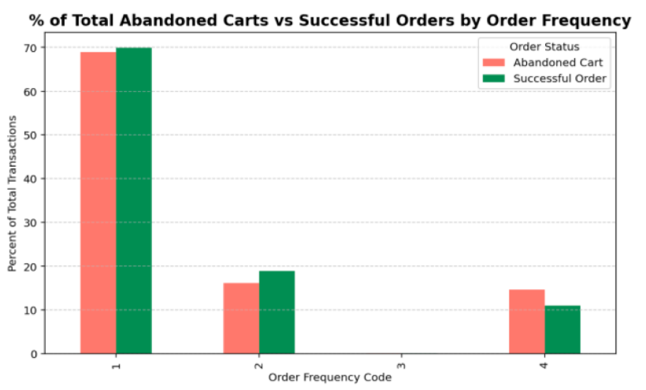

Courtney Graphs 2

### Tina

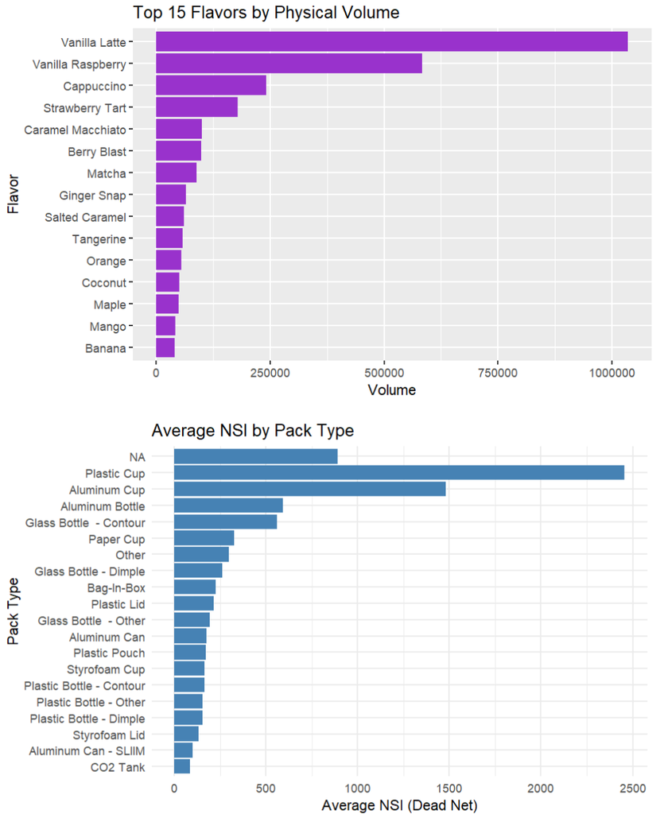

Tina Graphs 1

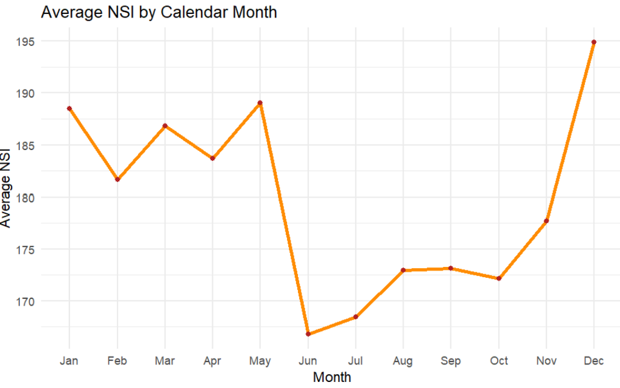

Tina Graphs 2

### Sabrina

[figure not shown]

Sabrina Graphs 1

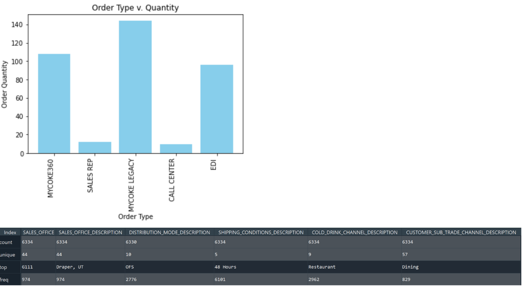

Sabrina Graphs 2

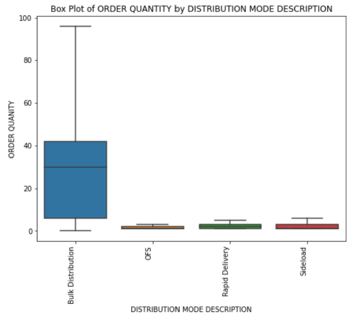

Sabrina Graphs 3

### Alphy

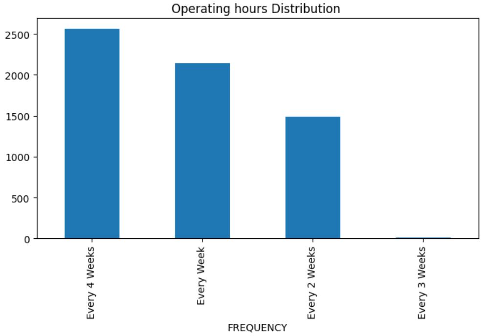

Alphy Graphs 1

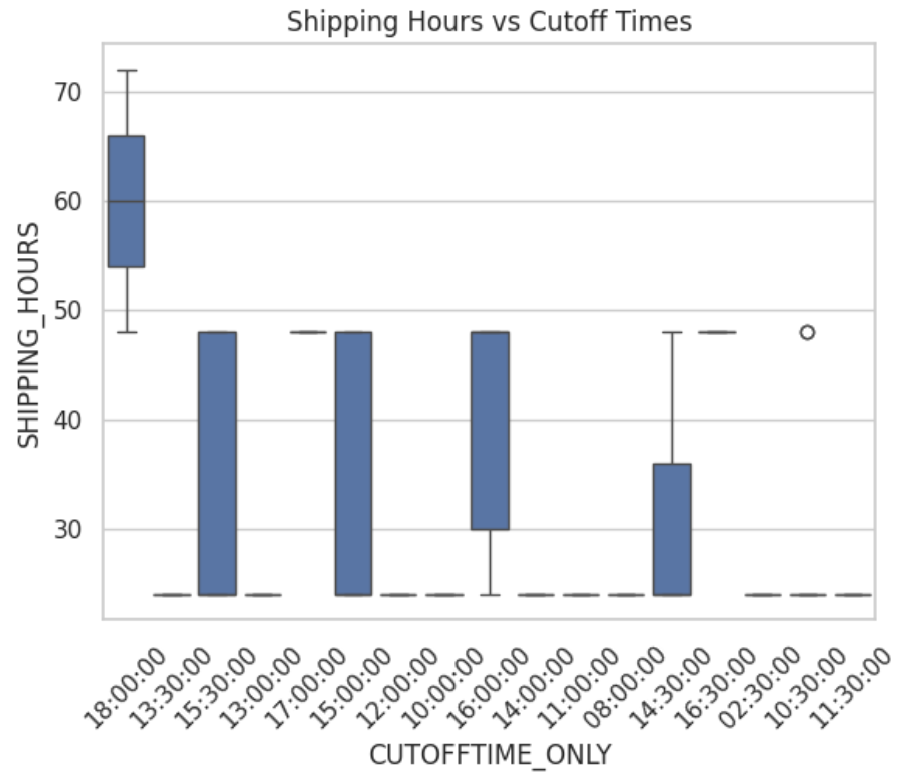

Alphy Graphs 2

## Results

### Tina

The notable points of the material.csv is the missing data in the BEV_CAT_DESC column, and that all of the MATERIAL_ID are distinctive while the combinations of flavors, packaging and sizes are duplicated, only 67% of these combinations are distinctive. Flavors have a large affect on volume sold as well as the most common pack type purchased as well.

### Sabrina

After playing around with some initial graphs, a sample size of 3,000 rows seemed to provide a relatively robust amount of information to draw conclusions from. The main numeric predictors to work with were NSI_DEAD_NET, ORDER_QUANTITY, and PHYSICAL_VOLUME amongst others. In terms of the Customer data table, this was largely a categorical data table, as seen by the summary table generated. Thus, many of the visualizations generated were box or barplots. Interestingly, the largest Sales Office locations for revenue generation were the Bellevue,WA, Denver, CO, Tacoma, WA, and Tempe, AZ regions. Perhaps, there is a shift in focus more towards the smaller revenue locations for targeting in terms of abandoned carts - it would make sense that larger revenue locations wouldn’t have abandoned carts to begin with to keep up with demand.

### Alphy

Most operations occur on a regular schedule, with the majority happening every 4 weeks (2,562 records), followed by weekly operations (2,140 records), and every 2 weeks (1,489 records). Only a small portion, 11 records, follow an every 3 weeks pattern.Most deliveries occur on weekdays, particularly between Tuesday and Friday, with very few scheduled for weekends

## Group Member Contributions

Due to the large amount of data SWIRE provided, we decided the best way to analyze everything was to have each group member use the Google Analytics, Orders, and Sales data tables as a core foundation for the other data tables to compare and work with. As such, each team member was designated these tables to expand upon with:

- Courtney - Visit Plan
- Alphonsinah - Order Cut Off Times & Operating Hours
- Sabrina - Customer
- Tina - Material

Of course, information such as Order Window had to be calculated using Visit Plan or Materials in the Customer table could be found in the Materials table - as such, if information was needed, we could pull from others if we needed to. All visualizations and summary tables from each team member were from the respected individual’s data table designation and we met as a group to share our findings for the next phase.

## Appendix: Code Used for Visualizations/Summary Tables

### Courtney

```python
Visual 1:
import matplotlib.pyplot as plt

status_counts = final_df["order_status"].value_counts()

plt.figure(figsize=(6, 6))
plt.pie(
    status_counts,
    labels=status_counts.index,
    autopct='%1.1f%%',
    startangle=90,
    colors=['lightcoral', 'mediumseagreen']
)
plt.title("Overall Cart Abandonment vs Successful Orders", fontsize=14, weight="bold")
plt.show()

import matplotlib.pyplot as plt

# Count events by device & order status
device_summary = (
    final_df.groupby(["DEVICE_CATEGORY", "order_status"])
    .size()
    .unstack(fill_value=0)
)

# Compute percentage of total within each order_status column
device_pct = device_summary.div(device_summary.sum(axis=0), axis=1) * 100

print("Percent of total transactions per order status:")
print(device_pct.round(2))

# Plot side-by-side bars (% of total abandoned/successful by device)
device_pct.plot(
    kind="bar",
    figsize=(8, 5),
    color=["salmon", "seagreen"]
)

plt.title("% of Total Abandoned Carts vs Successful Orders by Device Type", fontsize=14, weight="bold")
plt.xlabel("Device Category")
plt.ylabel("Percent of Total Transactions")
plt.grid(axis="y", linestyle="--", alpha=0.7)
plt.legend(title="Order Status")
plt.tight_layout()
plt.show()
```

[output not shown]

```python
Visual 2:
#Hourly abandonment patter
# Ensure hour column exists
final_df["hour"] = final_df["EVENT_TIMESTAMP"].dt.hour

# Group by hour and order status
hourly_abandon = (
    final_df.groupby(["hour", "order_status"])
    .size()
    .unstack(fill_value=0)
)

# Compute percentages within each order_status category
hourly_pct = hourly_abandon.div(hourly_abandon.sum(axis=0), axis=1) * 100

# Print results
print("Percent of each order type by hour of day:\n")
print(hourly_pct.round(2))

# Plot
hourly_pct.plot(kind="line", figsize=(10, 5), marker="o")

plt.title("% of Abandoned vs Successful Orders by Hour of Day", fontsize=14, weight="bold")
plt.xlabel("Hour of Day (EST)")
plt.ylabel("% of Each Order Type by Hour")
plt.xticks(range(0, 24))
plt.grid(True, linestyle="--", alpha=0.7)
plt.legend(title="Order Status")
plt.tight_layout()
plt.show()
```

```python
Visual 3:
# Group by frequency and order status
freq_summary = (
    final_df.groupby(["FREQUENCY", "order_status"])
    .size()
    .unstack(fill_value=0)
)

# Compute percentage of total transactions by order status
freq_pct = freq_summary.div(freq_summary.sum(axis=0), axis=1) * 100

print("Percent of total transactions per order status (by Frequency):")
print(freq_pct.round(2))

# Plot
freq_pct.plot(
    kind="bar",
    figsize=(8, 5),
    color=["salmon", "seagreen"]
)

plt.title("% of Total Abandoned Carts vs Successful Orders by Order Frequency", fontsize=14, weight="bold")
plt.xlabel("Order Frequency Code")
plt.ylabel("Percent of Total Transactions")
plt.grid(axis="y", linestyle="--", alpha=0.7)
plt.legend(title="Order Status")
plt.tight_layout()
plt.show()
```

### Tina

```r
#For the Top 15 flavors by Physical Volume {R}

material_sales %>%
  group_by(FLAVOUR_DESC) %>%
  summarise(Total_Volume = sum(PHYSICAL_VOLUME, na.rm = TRUE)) %>%
  arrange(desc(Total_Volume)) %>%
  slice_head(n = 15) %>%
  ggplot(aes(x = reorder(FLAVOUR_DESC, Total_Volume), y = Total_Volume)) +
  geom_col(fill = "darkorchid") +
  coord_flip() +
  labs(title = "Top 15 Flavors by Physical Volume", x = "Flavor", y = "Volume")
```

```r
#For the Average NSI by Pack Type

material_sales %>%
  group_by(PACK_TYPE_DESC) %>%
  summarise(Avg_NSI = mean(NSI_DEAD_NET, na.rm = TRUE)) %>%
  arrange(desc(Avg_NSI)) %>%
  ggplot(aes(x = reorder(PACK_TYPE_DESC, Avg_NSI), y = Avg_NSI)) +
  geom_col(fill = "steelblue") +
  coord_flip() +
  labs(
    title = "Average NSI by Pack Type",
    x = "Pack Type",
    y = "Average NSI (Dead Net)"
  ) +
  theme_minimal()
```

```r
#For Average NSI by Calendar Month

#confirm month/year
material_sales <- material_sales %>%
  mutate(
    Month = month(POSTING_DATE, label = TRUE),
    Year = year(POSTING_DATE)
  )
#aggregate nsi by month across year
monthly_pattern <- material_sales %>%
  group_by(Month) %>%
  summarise(Avg_NSI = mean(NSI_DEAD_NET, na.rm = TRUE)) %>%
  arrange(match(Month, month.abb))  # Ensures calendar order

#Plot
ggplot(monthly_pattern, aes(x = Month, y = Avg_NSI)) +
  geom_line(group = 1, color = "darkorange", size = 1.2) +
  geom_point(color = "firebrick") +
  labs(
    title = "Average NSI by Calendar Month",
    x = "Month",
    y = "Average NSI"
  ) +
  theme_minimal()
```

### Sabrina

```python
import numpy as np
import pandas as pd
import matplotlib.pyplot as plt
import seaborn as sns
import matplotlib.dates as mdates
from datetime import datetime
```

```python
#reading in the necessary csv files

google_analytics = pd.read_csv('google_analytics.csv')
orders = pd.read_csv('orders.csv')
sales = pd.read_csv('sales.csv')
visit_plan = pd.read_csv('visit_plan.csv')

customer = pd.read_csv('customer.csv')

#sampling a random 50,000 from the dataset to work with
#random_state set to 25 for reproducibility

sampled_google_analytics = google_analytics.sample(n=3000, random_state=25)
sampled_orders = orders.sample(n=3000, random_state=25)
sampled_sales = sales.sample(n=3000, random_state=25)
sampled_visit_plan = visit_plan.sample(n=3000, random_state=25)

customer.rename(columns={'CUSTOMER_NUMBER':'CUSTOMER_ID'}, inplace=True)

 # Inner merge (default): keeps only rows where 'customer_id' exists in both DataFrames
merged_df_inner = pd.merge(sampled_orders, sampled_google_analytics, on='CUSTOMER_ID', how='inner')
merged_df_inner = pd.merge(merged_df_inner, sampled_sales, on='CUSTOMER_ID', how='inner')
merged_df_inner = pd.merge(merged_df_inner, sampled_visit_plan, on='CUSTOMER_ID', how='inner')
merged_df_inner = pd.merge(merged_df_inner, customer, on='CUSTOMER_ID', how='inner')
```

```python
#First bar plot

# Create the bar plot
plt.bar(merged_df_inner.ORDER_TYPE, merged_df_inner.ORDER_QUANTITY, color='skyblue') # You can also specify a color

# Add labels and title
plt.xlabel('Order Type')
plt.ylabel('Order Quantity')
plt.title('Order Type v. Quantity')
plt.xticks(rotation=90, ha='right')

# Display the plot
plt.show()
```

```python
#First box plot

# Create the box plot
plt.figure(figsize=(8, 6)) # Optional: set figure size
sns.boxplot(x='CUSTOMER_SUB_TRADE_CHANNEL_DESCRIPTION', y='NSI_DEAD_NET', data=merged_df_inner, showfliers=False)

# Add title and labels
plt.title('Box Plot of NSI DEAD NET by CUSTOMER SUB TRADE CHANNEL DESCRIPTION')
plt.xlabel('CUSTOMER SUB TRADE CHANNEL DESCRIPTION')
plt.ylabel('NSI DEAD NET')
plt.xticks(rotation=90, ha='right')

# Display the plot
plt.show()
```

```python
#Second box plot

# Create the box plot
plt.figure(figsize=(8, 6)) # Optional: set figure size
sns.boxplot(x='DISTRIBUTION_MODE_DESCRIPTION', y='ORDER_QUANTITY', data=merged_df_inner, showfliers=False)

# Add title and labels
plt.title('Box Plot of ORDER QUANTITY by DISTRIBUTION MODE DESCRIPTION')
plt.xlabel('DISTRIBUTION MODE DESCRIPTION')
plt.ylabel('ORDER QUANTITY')
plt.xticks(rotation=90, ha='right')

# Display the plot
plt.show()
```

```python
#Summary table

summary_customer = customer.describe(include='object')
print("\nSummary for All Columns:")
print(summary_all)
```

### Alphy

```python
import pandas as pd

# Convert dates
operating_hours['CALLING_ANCHOR_DATE'] = pd.to_datetime(operating_hours['CALLING_ANCHOR_DATE'], errors='coerce')


# Missing values
print("Missing values per column:")
print(operating_hours.isnull().sum())


# Duplicates
print("\nNumber of duplicate rows:")
print(operating_hours.duplicated().sum())
operating_hours['FREQUENCY'].value_counts().plot(kind='bar', figsize=(8,4), title='Operating hours Distribution ')
```

```python
cutoff_times['CUTOFFTIME_CLEAN'] = cutoff_times['CUTOFFTIME__C'].astype(str).str.strip()


# Convert to datetime
cutoff_times['CUTOFFTIME_DT'] = pd.to_datetime(cutoff_times['CUTOFFTIME_CLEAN'], errors='coerce')


# Extract only the time
cutoff_times['CUTOFFTIME_ONLY'] = cutoff_times['CUTOFFTIME_DT'].dt.time


# Check results
print("Successfully parsed times:", cutoff_times['CUTOFFTIME_ONLY'].notnull().sum())
print("Failed parsing:", cutoff_times['CUTOFFTIME_ONLY'].isnull().sum())


# Convert 'SHIPPING_CONDITION_TIME' to numeric hours
cutoff_times['SHIPPING_HOURS'] = cutoff_times['SHIPPING_CONDITION_TIME'].str.replace("hrs","").astype(int)


# Quick check
print(cutoff_times[['SHIPPING_CONDITION_TIME', 'SHIPPING_HOURS']].head())


import seaborn as sns
import matplotlib.pyplot as plt


sns.boxplot(x='CUTOFFTIME_ONLY', y='SHIPPING_HOURS', data=cutoff_times)
plt.xticks(rotation=45)
plt.title("Shipping Hours vs Cutoff Times")
plt.show()
```